# Assignment 4

Corinna Hong

November 14, 2018

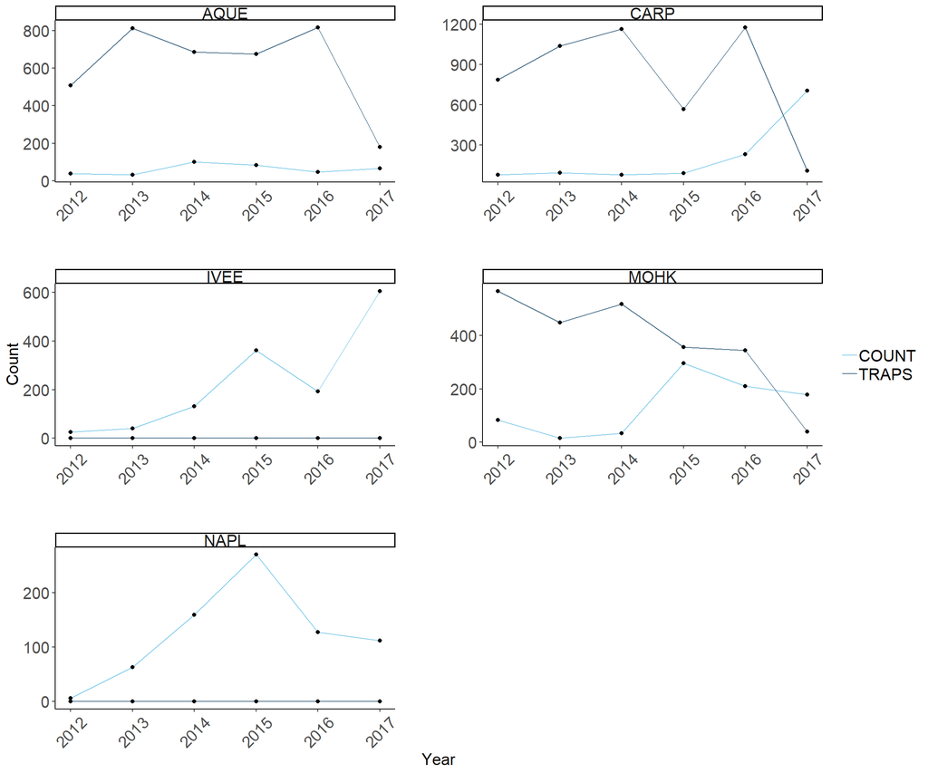

**Figure 1. Lobster Adundance and Fishing Pressure from 2012-2017.** Abundance (count) and fishing pressure (traps) per year for each of the five Long-Term Ecological Research (LTER) Sites in the Santa Barbara Channel. Abundance data was collected by divers in the late summer before the start of the fishing season and fishing pressure was determined by counting the number of commercial trap floats. Trap data was collected during the lobster fishing season. Data source: Reed, D. 2017. SBC LTER: Reef: Abundance, size and fishing effort for California Spiny Lobster (Panulirus interruptus), ongoing since 2012. Santa Barbara Coastal Long Term Ecological Research Project. doi:10.6073/pasta/81ce20b29614ec99d85d54907eaa3e8e

Lobster carapace length (mm) differed significantly in the five sitess studied (one-way ANOVA, F(4,1663) = 3.424, p < 0.009; Table 1). Tukey’s HSD revealed that carapace length at Naples Reef differed significantly from Isla Vista (pairwise p = 0.004) and Carpinteria (pairwise p = 0.02). The actual difference in mean carapace length between Naples Reef and Isla Vista is 4.78 mm. The difference in mean carapace length between NAples Reef and Carpinteria is 4 mm.

**Table 1. Summary statistics of lobster size (mm) by site in 2017.** Mean, standard deviation and variance of lobster carapace length collected at sites in the Santa Barbara Channel. Arroyo Quemado (AQUE), Carpinteria (CARP), and Mohawk Reef (MOHK) are non-marine protected areas. Isla Vista (IVEE) and Naples Reef (NAPL) are marine protected areas. Data source: Reed, D. 2017. SBC LTER: Reef: Abundance, size and fishing effort for California Spiny Lobster (Panulirus interruptus), ongoing since 2012. Santa Barbara Coastal Long Term Ecological Research Project. doi:10.6073/pasta/81ce20b29614ec99d85d54907eaa3e8e

| Site | Mean | Standard Deviation | Variance | Sample Size |
| --- | --- | --- | --- | --- |
| AQUE | 73.90 | 11.89 | 141.40 | 67 |
| CARP | 72.23 | 13.21 | 174.48 | 705 |
| MOHK | 72.00 | 9.28 | 86.12 | 178 |
| IVEE | 71.45 | 14.32 | 205.06 | 606 |
| NAPL | 76.23 | 11.39 | 129.69 | 112 |

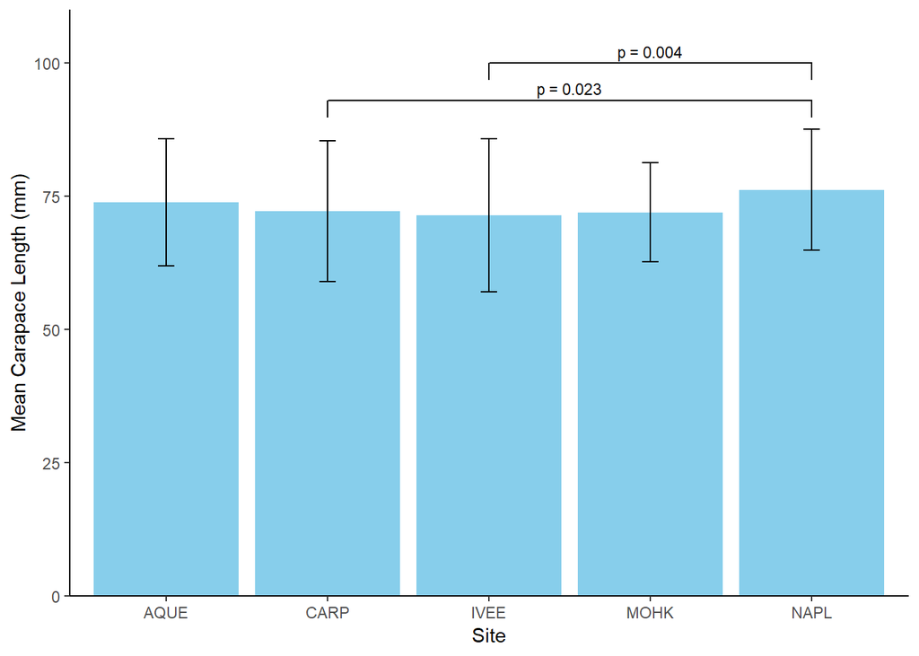

**Figure 2. Mean lobster size (mm) by site in 2017.** Mean carapace length (mm) of lobsters measured at five different locations: Arroyo Quemado (AQUE, n = 67), Carpinteria (CARP, n = 705), Isla Vista (IVEE, n = 606), Mohawk Reef (MOHK, n = 178) and Naples Reef (NAPL, n = 112). Error bars indicate ± 1 standard deviation. Mean carapace length only differed significantly between CARP and NAPL, and IVEE and NAPL while all other pairwise comparisons yielded no significant difference (one-way ANOVA, F(4) = 3.424, p = 0.0085) with post-hoc Tukey’s HSD (α = 0.05). Brackets indicate significant differences between sites with respective p-values. Data source: Reed, D. 2017. SBC LTER: Reef: Abundance, size and fishing effort for California Spiny Lobster (Panulirus interruptus), ongoing since 2012. Santa Barbara Coastal Long Term Ecological Research Project. doi:10.6073/pasta/81ce20b29614ec99d85d54907eaa3e8e.

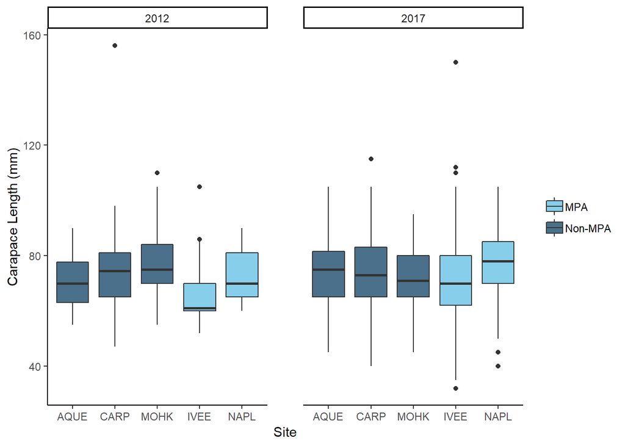

**Figure 3. Lobster size at MPA and non-MPA sites between 2012 and 2017.** Carapace length (mm) of California spiny lobsters (*Panulirus interruptus*) at each site. Shading represents samples taken from marine protected areas and non-marine protected areas. Data source: Reed, D. 2017. SBC LTER: Reef: Abundance, size and fishing effort for California Spiny Lobster (Panulirus interruptus), ongoing since 2012. Santa Barbara Coastal Long Term Ecological Research Project. doi:10.6073/pasta/81ce20b29614ec99d85d54907eaa3e8e.

**Table 2. Proportion of observed lobsters above the legal carapace length** Lobsters with a carapace length of 82.6 mm or above are considered legal and can be trapped. There is a significant difference in proportions of observed lobsters above the legal minimum across all five sites (*X<sup>2</sup>* = 18.497, df = 4, p < .001). Shading represents samples taken from marine protected areas and non-marine protected areas. Data source: Reed, D. 2017. SBC LTER: Reef: Abundance, size and fishing effort for California Spiny Lobster (Panulirus interruptus), ongoing since 2012. Santa Barbara Coastal Long Term Ecological Research Project. doi:10.6073/pasta/81ce20b29614ec99d85d54907eaa3e8e

|  | Legal | Not Legal |
| --- | --- | --- |
| AQUE | 0.24 | 0.76 |
| CARP | 0.25 | 0.75 |
| MOHK | 0.13 | 0.87 |
| IVEE | 0.21 | 0.79 |
| NAPL | 0.33 | 0.67 |